# Feature_Analysis_and_Engineering

```python
# Data Manipulation Modules
import pandas as pd
import numpy as np
import scipy as sp
import numpy as np
import math
import scipy.stats as stats
from collections import Counter

# Visualizations
import seaborn as sns
import matplotlib.pyplot as plt

#Set random_state
random_state = 1

# Managing Warnings
import warnings
warnings.filterwarnings('ignore')
```

```python
Merged = pd.read_pickle("../data/trainable.pkl")
```

```python
len(Merged)
```

```
43607
```

# Exploratory Data Analysis

Now the fun begins! We are left with 16 Raw Features (and 2 previously engineered features), and 1 Target Variable, as follows:

## Categories of Features

- #### Numerical Variables
  - *Discrete*
    1. **Yards to Go** - Yards to gain a first down (or to goalline)
    2. **Time left in Quarter** - Time, in minutes and seconds, left in the current quarter
  - *Continuous*
    1. **Pre-Snap Cushion** - distance between the receiver and the defender who lines up across from them at snap (yds)
    2. **Air Yards** - vertical distance down the field a receiver is when the pass arrives
    3. **Air Distance** - straight line distance from the QB to the targeted recevier when the pass arrives (yds)
    4. **Air Time** - time the pass is in the air (in seconds)
    5. **TTT** - time from when the ball is snapped to when it is thrown (in seconds)
    6. **QB Separation** - distance from the QB to the nearest defender to the QB at the time of pass (yds)
    7. **Receiver Dist from Sideline** - distance from targeted receiver and nearest sideline when pass arrives (yds)
    8. **Endzone Dist** - the distance a reciever is from the back of the nearest endzone (yds)
    9. **QBP** - A binary value (1 or 0) that indicates if the QB was pressured
    10. **QB Scramble Yards** - The distance the QB travels on a play before throwing the pass
- #### Categorical
  - *Non-Ordinal*
    1. **Position of Nearest Defender** - SS, OLB, DL, CB
    2. **Pre-Snap Receiver Location** - Wide, Slot, Tight
  - *Ordinal*
    1. **Quarter**
    2. **Down**

Lets create a correlation heatmap to see how linearly correlated these features are with Receiver Separation:

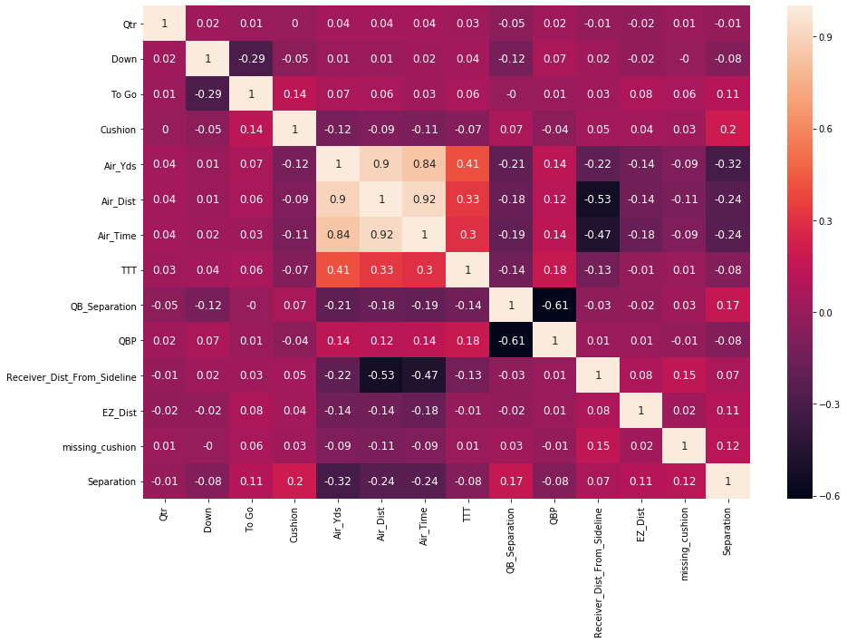

```python
fig =  plt.subplots(figsize=(15,10))
ax = sns.heatmap(round(Merged.corr(method = 'pearson'), 2), annot=True, annot_kws={"size": 12})
```

If we look at the bottom row of the heatmap, we can see than **Air Yards** seems to be most correlated to Separation (r = -.32).

## Feauture Analysis: Quarter

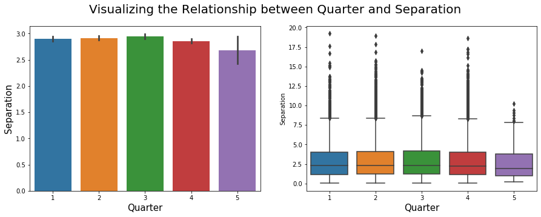

```python
# Show some plots to visualize relationship beteen Quarter and Separation

fig_dims = (15, 6)
fig, (ax1, ax2) = plt.subplots(ncols=2, figsize=(15,5))
fig.suptitle('Visualizing the Relationship between Quarter and Separation', fontsize=20)

    # Draw the density plots
sns.barplot(x='Qtr', y='Separation', data=Merged, ax =ax1)
sns.boxplot(x='Qtr', y='Separation', data=Merged, ax = ax2)

ax1.set_xlabel('Quarter', fontsize=15)
ax2.set_xlabel('Quarter', fontsize=15)
A = ax1.set_ylabel('Separation', fontsize=15)
```

```python
Qtr_df = Merged[['Qtr', 'Separation']]
Qtr_df.groupby(['Qtr']).mean().round({'Separation': 2}).sort_values('Qtr', ascending = True)
```

| Qtr | Separation |
| --- | --- |
| 1 | 2.90 |
| 2 | 2.91 |
| 3 | 2.95 |
| 4 | 2.86 |
| 5 | 2.69 |

Just by looking at these distributions, I cannot tell whether quarter has any discernable affect on Separation, especially within a regulation game.

It looks like passes in overtime (the 5th quarter, in this case) have the lowest average separation, which makes sense, as the stakes are the highest. That said, before I decide to include/remove the feature, I want to run some t-tests to see if the distributions are statistically different from each other. In other words, is the fact that the average separation for targets in regulation (quarters 1-4) higher than targets in overtime (quarter 5) significant? Or could this happen with any random subestting of data distributed like this?

## Feature Engineering - 'Is Overtime'

I am going to separate all regulation Separations (quarters 1-4) with overtime (quarter 5) to prep my t-test:

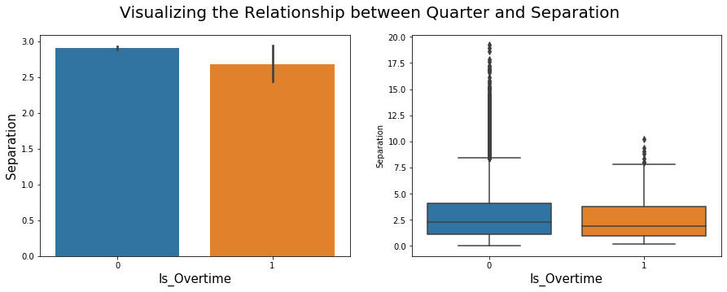

```python
#Create new columns called 'Is_Overtime' that is 1 in overtime and 0 in all other quarter
Test = Merged.copy()

Test['Is_Overtime'] = 0
Test.loc[Test['Qtr'] == 5, 'Is_Overtime'] = 1

# Show some plots to visualize relationship beteen Quarter and Separation

fig_dims = (15, 6)
fig, (ax1, ax2) = plt.subplots(ncols=2, figsize=(15,5))
fig.suptitle('Visualizing the Relationship between Quarter and Separation', fontsize=20)

    # Draw the density plots
sns.barplot(x='Is_Overtime', y='Separation', data=Test, ax = ax1)
sns.boxplot(x='Is_Overtime', y='Separation', data=Test, ax = ax2)

ax1.set_xlabel('Is_Overtime', fontsize=15)
ax2.set_xlabel('Is_Overtime', fontsize=15)
A = ax1.set_ylabel('Separation', fontsize=15)
```

```python
rvs1 = Test[Test['Is_Overtime'] == 0]['Separation']
rvs2 = Test[Test['Is_Overtime'] == 1]['Separation']

p_value = round(stats.ttest_ind(rvs1,rvs2)[1], 5)

print('Our p value is ' + str(p_value))
print('Since our p value > 0.05, we cannot reject the null hypothesis, the two disributions are statistically indiscernable.')
```

```
Our p value is 0.11145
Since our p value > 0.05, we cannot reject the null hypothesis, the two disributions are statistically indiscernable.
```

It's close, but because of our p value is not less than .05, I will **NOT** include 'Is_Overtime in my modeling/features selection process.

# Feature Analysis: Down

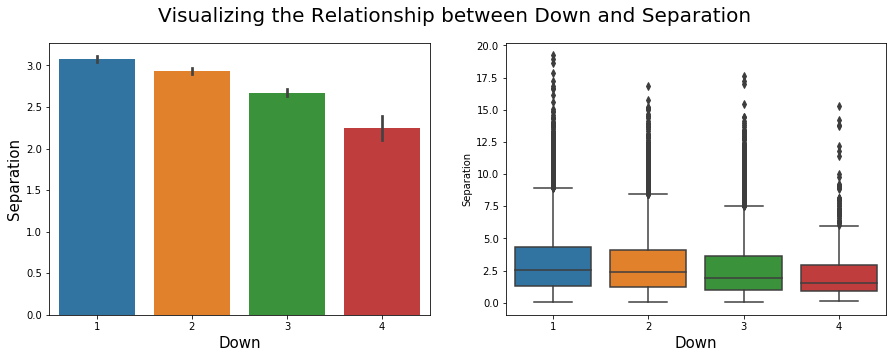

```python
fig_dims = (15, 6)
fig, (ax1, ax2) = plt.subplots(ncols=2, figsize=(15,5))
fig.suptitle('Visualizing the Relationship between Down and Separation', fontsize=20)

    # Draw the density plots
sns.barplot(x='Down', y='Separation', data=Merged, ax =ax1)
sns.boxplot(x='Down', y='Separation', data=Merged, ax = ax2)

ax1.set_xlabel('Down', fontsize=15)
ax2.set_xlabel('Down', fontsize=15)
ax1.set_ylabel('Separation', fontsize=15)
```

```python
Down_df = Merged[['Down', 'Separation']]
Down_df.groupby(['Down']).mean().round({'Separation': 2}).sort_values('Down', ascending = True)
```

| Down | Separation |
| --- | --- |
| 1 | 3.08 |
| 2 | 2.93 |
| 3 | 2.67 |
| 4 | 2.25 |

There seems to be a correlation between what down it is and the average separation of the targeted receiver. This isn't too surprising, as we would expect defenses to play more closely in more high-stakes/important downs. Also, as downs get higher, yards to go should get smaller, which should cause average separation to decrease, but can confirm these suspicions below.

Nothing more needs to be done here, we will keep Down in the data set and move on.

# Feature Analysis: Yards to Go

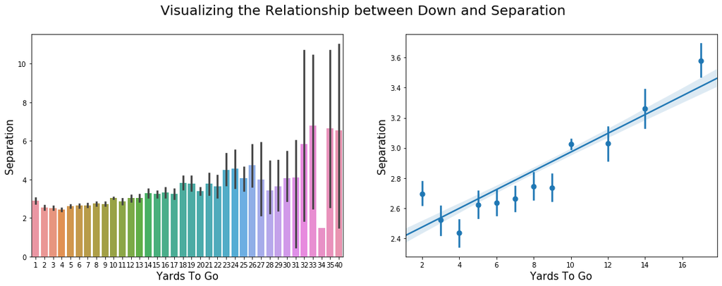

```python
fig_dims = (18, 6)
fig, (ax1, ax2) = plt.subplots(ncols=2, figsize=(18,6))
fig.suptitle('Visualizing the Relationship between Down and Separation', fontsize=20)

    # Draw the density plots
sns.barplot(x='To Go', y='Separation', data=Merged, ax =ax1)
sns.regplot(x='To Go', y='Separation', data=Merged, ax =ax2, x_bins = 25)

ax1.set_xlabel('Yards To Go', fontsize=15)
ax2.set_xlabel('Yards To Go', fontsize=15)
ax1.set_ylabel('Separation', fontsize=15)
A = ax2.set_ylabel('Separation', fontsize=15)
```

As we saw above, the correlation coefficient of raw 'Yards To Go' to 'Separation' was 0.11.

I have a suspicion that we see a little jump in average separation near 1-2 yards to go because these are obvious runnung situations. I am speculating that defenses are expecting a running play, and when a pass is attempted, recevier separation is higher on average than similar yards to go sitautions.

Also, it's worth nothing the *tiny* error bar on the point above 10 yards to go, suggesting there's probably a lot of points there (which makes sense).

how many pass plays since 2017 have 10 yards to go?

```python
print(len(Merged[Merged['To Go'] == 10]))
print(str(round(((len(Merged[Merged['To Go'] == 10])/len(Merged))*100), 2)) + '% of the dataset')
```

```
19211
44.05% of the dataset
```

## Feature Analysis: Yards to Go, by Down

I am curious to know more about the relationship between down and yards to go, and their relationship to receivers separation.

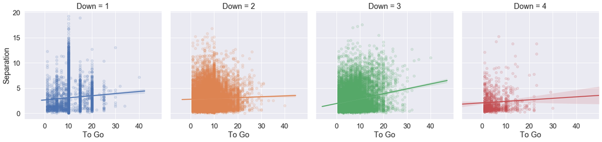

```python
A = sns.set(font_scale=1.5)
B = sns.lmplot(x='To Go', y="Separation", col='Down', hue= 'Down',
               data=Merged, height=5, scatter_kws={'alpha':0.15})
```

All of the plots show that Yards to Go and Separation are positively correlated (at least slightly), but **3rd down** shows this relationship most clearly, that yards to go is most predictive on 3rd down

Lets check these correlation values of yards to go, but separated by down.

```python
Corr = Merged.groupby('Down')[['To Go','Separation']].corr().iloc[0::2][['Separation']].round(3)
Corr
```

| Down |  | Separation |
| --- | --- | --- |
| 1 | To Go | 0.042 |
| 2 | To Go | 0.032 |
| 3 | To Go | 0.201 |
| 4 | To Go | 0.068 |

# Feature Engineering: Down & Distance

Now that we have looked at 'Down' and 'Yards to Go' already, I want to combine them to create a 'Down & Distance' feature. Each of these features alone does not seem to have a lot predictive power, but combined, perhaps they will be more helpful.

```
0.09916492826224842
```

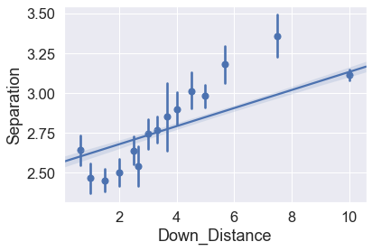

```python
Merged['Down_Distance'] = Merged['To Go']/Merged['Down']

sns.regplot(x=Merged['Down_Distance'], y=Merged['Separation'], data=Merged, x_bins = 25)
Merged['Down_Distance'].corr(Merged['Separation'])
```

Since **44% of pass plays** in this dataset occur with 10 yards to go, the lack of variance limits the predictive power of yards to go. This should be slightly mitigated with the creation of this feature by separating that one point into 4 separate points when including down as the denominator. The linear correlation isn't noticably better, but non-linear algorithms (Random Forest or Extreme Gradient Boosting) could be able to find more complex relationships more easily and potentially help with predictions.

# Feature Engineering: Yds_to_Success

Though yards to go is helpful in describing how tightly a defense might cover opposing receviers, offenses aren't always looking to gain all of the yards they need on every down. In fact, Aaron Schatz of [Football Outsiders](https://www.footballoutsiders.com/info/methods#:~:text=On%20first%20down%2C%20a%20play,first%20down%20is%20considered%20success) has a very specific definition of offensive 'success' that I will use:

```python
def Success(df):
    if df['Down'] == 1:
        val = df['To Go']*.45
    elif df['Down'] == 2:
        val = df['To Go']*.55
    else:
        val = df['To Go']
    return val
```

```python
Merged['Yds_to_Success'] = 0
Merged['Yds_to_Success'] = Merged.apply(Success, axis = 1)
```

```
0.06671573767570826
```

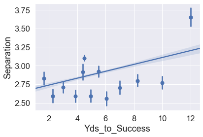

```python
sns.regplot(x=Merged['Yds_to_Success'], y=Merged['Separation'], data=Merged, x_bins = 20)
Merged['Yds_to_Success'].corr(Merged['Separation'])
```

# Feature Analysis: Air Yards

**Air Yards** - the distance a pass is from the line of scrimmage, and can be negative if the pass is thrown to a reciever behind the line of scrimmage

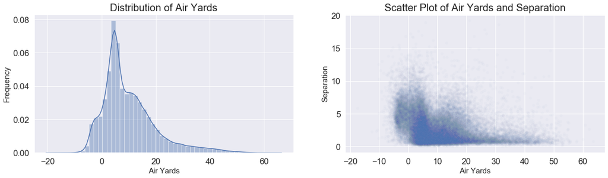

```python
x = Merged['Air_Yds']
y = Merged['Separation']

fig, (ax1, ax2) = plt.subplots(ncols=2, figsize=(20, 5))


sns.distplot(x, ax = ax1)
sns.scatterplot(x=x, y = y, alpha = 0.02)

ax1.set_title('Distribution of Air Yards', fontsize = 20)
ax1.set_ylabel('Frequency', fontsize = 15)
ax1.set_xlabel('Air Yards', fontsize = 15)

ax2.set_title('Scatter Plot of Air Yards and Separation', fontsize = 20)
ax2.set_ylabel('Separation', fontsize = 15)
A = ax2.set_xlabel('Air Yards', fontsize = 15)
```

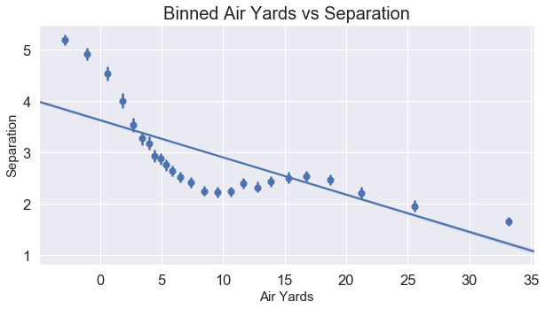

```python
x = Merged['Air_Yds']
y = Merged['Separation']

fig, ax = plt.subplots(figsize = (10,5))
sns.regplot(x=x, y = y, x_bins = 25)

ax.set_title('Binned Air Yards vs Separation', fontsize = 20)
ax.set_ylabel('Separation', fontsize = 15)
A = ax.set_xlabel('Air Yards', fontsize = 15)
```

# Feature Engineering: Yds_to_1st

I understand that yards to go provides context to give defenses an idea of how they should defend a recevier, so I believe that combining it with air yards should create an even more insightful metric.

Let's take a look:

```
-0.3462118538704928
```

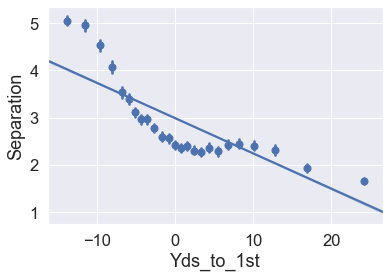

```python
Merged['Yds_to_1st'] = (Merged['Air_Yds']-Merged['To Go'])

sns.regplot(x=Merged['Yds_to_1st'], y=Merged['Separation'], data=Merged, x_bins = 25)
Merged['Yds_to_1st'].corr(Merged['Separation'])
```

This value, 'Yds_beyond_1st', is telling us how far the targeted receiver was from the first down marker when the pass arrived. As we can see, this value has correlation value of .35 with Separation, which is more correlated to separation than air yards by itself. Sweet!

# Feature Engineering: yds_beyond_success

This feature aims to do similarly what we did above but using, what should be, a more inisghtful yardage distance than the first down marker, but rather what the offense would consider a success (as we defined earlier).

```
-0.33297954462477214
```

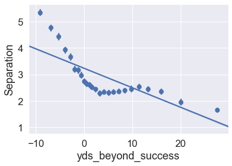

```python
Merged['yds_beyond_success'] = (Merged['Air_Yds']-Merged['Yds_to_Success'])

sns.regplot(x=Merged['yds_beyond_success'], y=Merged['Separation'], data=Merged, x_bins = 25)
Merged['yds_beyond_success'].corr(Merged['Separation'])
```

This value is very similar to 'Yds_beyond_1st', but tells us how far the targeted receiver was from the the yardage needed for the play to be deemed successful. This value has correlation value of .33 with Separation, which is slightly less than our previous feature, and will be highly correlated to Air_Yds. For the sake of simplicity, I will most likely choose one (maybe 2) of these features in my final model, but I will wait until the modeling process results before dropping this outright yet.

# Feature Analysis: Cushion

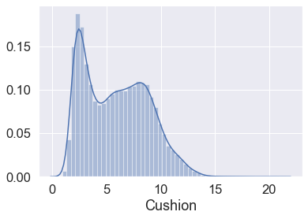

```python
fig = sns.distplot(Merged['Cushion'])
```

I am noticing the **bimodal** nature of this distribution, suggesting that defenders usually either line up close to the receiver (think Press coverage), or quite far off of them (Off coverage). From this, I want to further look into how these two types of cushion relate to the recievers separation

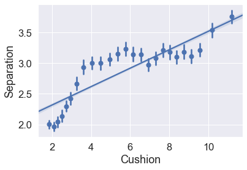

```python
y = Merged['Separation']
x = Merged['Cushion']
p1 = sns.regplot(x=x, y=y, data=Merged, x_bins = 25)
```

## Feature Analysis: Cushion_Type

Seen in the binned scatter plot above, we can see that, on the whole, an increase in cushion leads (or at least is linearly correlated to) an increase in separation, up until about 3 yards of cushion, then levels off, then increases again after 9 yards. What would this look like if these yardage boundaries were grouped together?

```python
Merged['Cushion_Type'] = 'Regular'
Merged['Cushion_Type'].loc[Merged['Cushion'] <= 3] = 'Press'
Merged['Cushion_Type'].loc[Merged['Cushion'] >= 9] = 'Off'
```

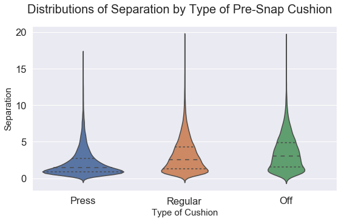

```python
#Look at the distributions of Separation by Pre-Snap Receiver Location

fig = plt.figure(figsize=(9,5))

sns.violinplot(x="Cushion_Type", y="Separation", data=Merged, inner = 'quartile', order = ['Press', 'Regular', 'Off'])

plt.suptitle('Distributions of Separation by Type of Pre-Snap Cushion', fontsize = 20)
plt.ylabel('Separation', fontsize = 15)
A = plt.xlabel('Type of Cushion', fontsize = 15)
```

```python
Pressed = Merged[['Cushion_Type', 'Separation']]
Pressed.groupby(['Cushion_Type']).mean().round({'Separation': 2}).sort_values('Separation', ascending = False)
```

| Cushion_Type | Separation |
| --- | --- |
| Off | 3.46 |
| Regular | 3.06 |
| Press | 2.11 |

Players who were pressed at the line of scrimmage (less than 3 yards of pre-snap cushion) saw roughly **a yard of separation less** at pass arrival than receivers who were not pressed.

To note, I **do not** think that a categorical value like Cushion_Type is nearly as insightful as a continuous variable like Cushion itself, but I wanted to show these differences clearly.

# Feature Analysis: Air Time

**Air Time** - the the time from the ball is released for the pass to the time the pass arrives to the targeted receiver.

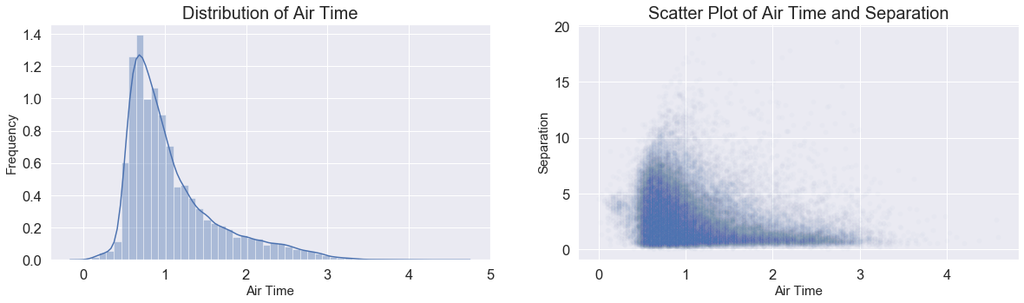

```python
x = Merged['Air_Time']
y = Merged['Separation']

fig, (ax1, ax2) = plt.subplots(ncols=2, figsize=(20, 5))


sns.distplot(x, ax = ax1)
sns.scatterplot(x=x, y = y, alpha = 0.02)

ax1.set_title('Distribution of Air Time', fontsize = 20)
ax1.set_ylabel('Frequency', fontsize = 15)
ax1.set_xlabel('Air Time', fontsize = 15)

ax2.set_title('Scatter Plot of Air Time and Separation', fontsize = 20)
ax2.set_ylabel('Separation', fontsize = 15)
A = ax2.set_xlabel('Air Time', fontsize = 15)
```

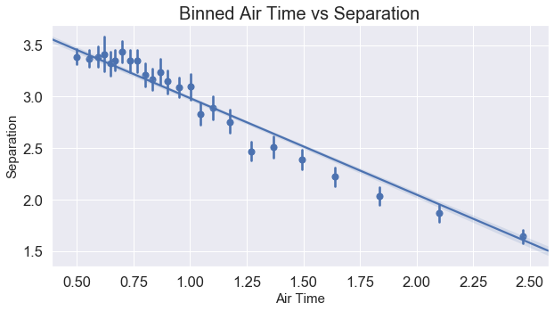

```python
x = Merged['Air_Time']
y = Merged['Separation']

fig, ax = plt.subplots(figsize = (10,5))
sns.regplot(x=x, y = y, x_bins = 25)

ax.set_title('Binned Air Time vs Separation', fontsize = 20)
ax.set_ylabel('Separation', fontsize = 15)
A = ax.set_xlabel('Air Time', fontsize = 15)
```

```python
print('Spearman (rank) correlation: ' + str(round(x.corr(y, method = 'spearman'), 3)) + ' between Air Time and Separation')
print('Pearson (linear) correlation: ' + str(round(x.corr(y, method = 'pearson'), 3)) + ' between Air Time and Separation')
```

```
Spearman (rank) correlation: -0.273 between Air Time and Separation
Pearson (linear) correlation: -0.238 between Air Time and Separation
```

# Feature Analysis: QB Separation

**QB Separation** - The distance between the QB and the nearest defender (usually a pass rusher) to the QB at the time the pass in thrown.

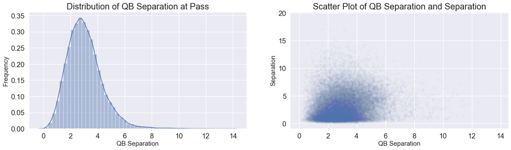

```python
x = Merged['QB_Separation']
y = Merged['Separation']

fig, (ax1, ax2) = plt.subplots(ncols=2, figsize=(20, 5))


sns.distplot(x, ax = ax1)
sns.scatterplot(x=x, y = y, alpha = 0.02)

ax1.set_title('Distribution of QB Separation at Pass', fontsize = 20)
ax1.set_ylabel('Frequency', fontsize = 15)
ax1.set_xlabel('QB Separation', fontsize = 15)

ax2.set_title('Scatter Plot of QB Separation and Separation', fontsize = 20)
ax2.set_ylabel('Separation', fontsize = 15)
A = ax2.set_xlabel('QB Separation', fontsize = 15)
```

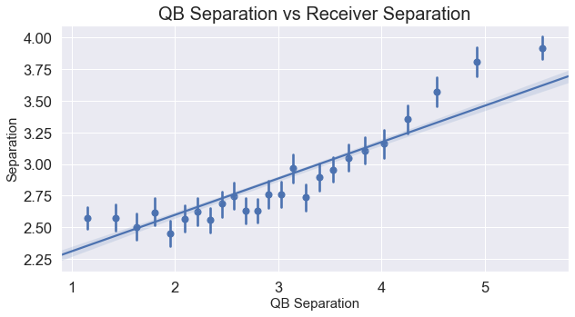

```python
x = Merged['QB_Separation']
y = Merged['Separation']

fig, ax = plt.subplots(figsize = (10,5))
sns.regplot(x=x, y = y, x_bins = 25)

ax.set_title('QB Separation vs Receiver Separation', fontsize = 20)
ax.set_ylabel('Separation', fontsize = 15)
A = ax.set_xlabel('QB Separation', fontsize = 15)
```

This binned plot above describes a rough linear correlation between separation and QB separation. This would suggest that when QBs are under pressure, they cannot deliver an accurate pass, and therefore their receiver's separation is lower.

# Feature Analysis: Receiver Distance from Sideline as Pass Arrival

This feature quantifies the distance (in yards) from the targeted receiver and the nearest sideline at the time pass arrives.

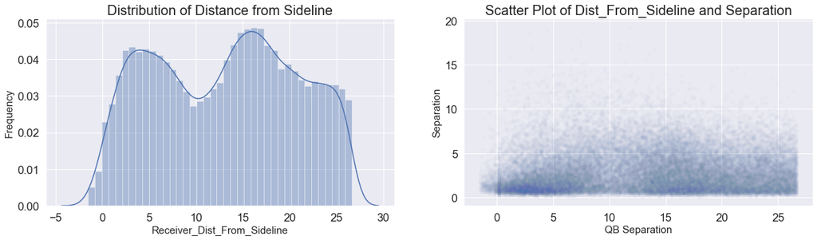

```python
x = Merged['Receiver_Dist_From_Sideline']
y = Merged['Separation']

fig, (ax1, ax2) = plt.subplots(ncols=2, figsize=(20, 5))

sns.distplot(x, ax = ax1)
sns.scatterplot(x=x, y = y, alpha = 0.02)

ax1.set_title('Distribution of Distance from Sideline', fontsize = 20)
ax1.set_ylabel('Frequency', fontsize = 15)
ax1.set_xlabel('Receiver_Dist_From_Sideline', fontsize = 15)

ax2.set_title('Scatter Plot of Dist_From_Sideline and Separation', fontsize = 20)
ax2.set_ylabel('Separation', fontsize = 15)
A = ax2.set_xlabel('QB Separation', fontsize = 15)
```

```python
print('Spearman (rank) correlation: ' + str(round(x.corr(y, method = 'spearman'), 3)) + ' between Sideline Distance and Separation')
print('Pearson (linear) correlation: ' + str(round(x.corr(y, method = 'pearson'), 3)) + ' between Sideline Distance and Separation')
```

```
Spearman (rank) correlation: 0.101 between Sideline Distance and Separation
Pearson (linear) correlation: 0.067 between Sideline Distance and Separation
```

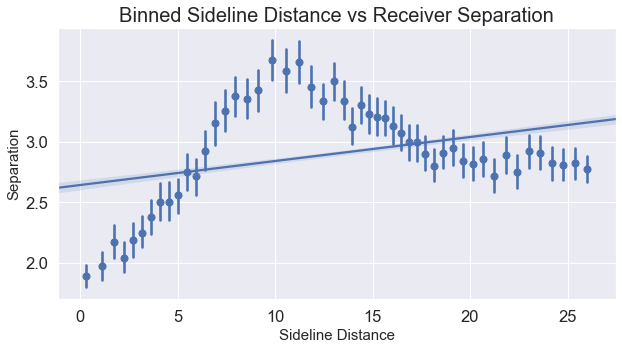

```python
x = Merged['Receiver_Dist_From_Sideline']
y = Merged['Separation']

fig, ax = plt.subplots(figsize = (10,5))
sns.regplot(x=x, y = y, x_bins = 50)

ax.set_title('Binned Sideline Distance vs Receiver Separation', fontsize = 20)
ax.set_ylabel('Separation', fontsize = 15)
A = ax.set_xlabel('Sideline Distance', fontsize = 15)
```

Average Separation decreases steadily once the receiver gets 10 yards away from the sideline.

My speculation is that recevier distance from the sideline only begins to be a factor once they get into more threatening situations. I am going to now try to build a stat that captures this using 'Yds to 1st' and 'Sideline Distance'

# Feature Engineering: Sideline Air Yards

I beleive sideline distance only matters when the receiver is threatening to a defense (stretching them downfield) so I want to combine Air_Yds and 'Receiver_Dist_From_Sideline' in a way that gets larger when either 'Receiver_Dist_From_Sideline' is low or 'Air_Yds' are high.

```
-0.2666525516502472
```

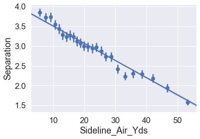

```python
Merged['Sideline_Air_Yds'] = (Merged['Air_Yds'])+(27-Merged['Receiver_Dist_From_Sideline'])

A = sns.regplot(x=Merged['Sideline_Air_Yds'], y=Merged['Separation'], data=Merged, x_bins = 25)
Merged['Sideline_Air_Yds'].corr(Merged['Separation'])
```

# Feature Analysis: Distance Receiver is from Back of Endzone

This feature is defined as the distance (in yards) that there recevier is from the back of the endzone (in the direction the play is facing).

My initial thought is that this feature will be noise until the receiver gets within some yardage from the back of the endzone, and then get lower as it endzone distance goes to 0.

For refence, EZ_distance does not get higher than 60 because it is not tracked until a receier crosses midfield (which is 60 yards from back of endzone)

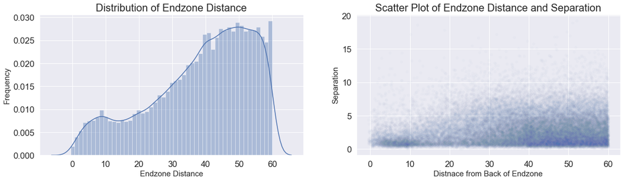

```python
x = Merged['EZ_Dist']
y = Merged['Separation']

fig, (ax1, ax2) = plt.subplots(ncols=2, figsize=(20, 5))

sns.distplot(x, ax = ax1)
sns.scatterplot(x=x, y = y, alpha = 0.02)

ax1.set_title('Distribution of Endzone Distance', fontsize = 20)
ax1.set_ylabel('Frequency', fontsize = 15)
ax1.set_xlabel('Endzone Distance', fontsize = 15)

ax2.set_title('Scatter Plot of Endzone Distance and Separation', fontsize = 20)
ax2.set_ylabel('Separation', fontsize = 15)
A = ax2.set_xlabel('Distnace from Back of Endzone', fontsize = 15)
```

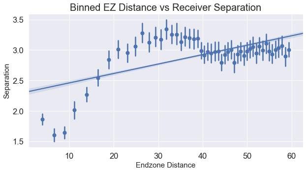

```python
x = Merged['EZ_Dist']
y = Merged['Separation']

fig, ax = plt.subplots(figsize = (10,5))
sns.regplot(x=x, y = y, x_bins = 50)

ax.set_title('Binned EZ Distance vs Receiver Separation', fontsize = 20)
ax.set_ylabel('Separation', fontsize = 15)
A = ax.set_xlabel('Endzone Distance', fontsize = 15)
```

# Categorical Features

## Position of Nearest Defender

```python
Pos_df = Merged[['Nearest_Def_Position', 'Separation']]
Position = Pos_df.groupby(['Nearest_Def_Position']).mean().round({'Separation': 2}).sort_values('Separation', ascending = False)
Position['Play_Counts'] = Pos_df.groupby(['Nearest_Def_Position']).count()
Position
```

| Nearest_Def_Position | Separation | Play_Counts |
| --- | --- | --- |
| NT | 5.13 | 115 |
| DE | 5.12 | 878 |
| DT | 5.02 | 625 |
| DL | 4.50 | 17 |
| OLB | 3.69 | 3327 |
| LB | 3.66 | 1511 |
| MLB | 3.36 | 1518 |
| ILB | 3.34 | 2598 |
| WR | 3.24 | 16 |
| SS | 2.95 | 3702 |
| FS | 2.89 | 4078 |
| DB | 2.59 | 1489 |
| S | 2.58 | 383 |
| CB | 2.53 | 23345 |
| FB | 1.77 | 2 |
| SAF | 1.38 | 2 |
| TE | 1.08 | 1 |

It looks there are a lot of different positions listed here, but 20K plays belong just to CBs. I don't think there is much difference between positions like OLB and ILB, as well as DL vs DE vs DT. To this end, I will consolidate these categories to make it simpler to understand. Also, it looks like a few offensive skill players have been used on defense occasionally. Since they represent ~20 rows, I am going to drop them.

```python
# Dropping all rows where skill position players that were the ones who were the nearest defender at pass arrival
skillpos = ['WR', 'TE', 'FB', 'RB', 'QB']
Merged = Merged[~Merged['Nearest_Def_Position'].isin(skillpos)]
```

## Feature Engineering: Clean up Defender Position Categories

```python
LB = ['OLB', 'ILB', 'MLB', 'LB']
DL = ['DL', 'DE', 'DT', 'NT']
CB = ['CB', 'DB']
SAFE = ['SAF', 'S', 'FS', 'SS']

def NearestPos(row):

    #LBs
    if row in LB:
        return 'LB'

    #DLs
    elif row in DL:
        return 'DL'

    #CBs
    elif row in CB:
        return 'CB'

    #Safeties
    elif row in SAFE:
        return 'STY'
    else:
        return 'Other'


Merged['NDP'] = ''
Merged['NDP'] = Merged['Nearest_Def_Position'].copy().apply(NearestPos)
```

```python
NDP_df = Merged[['NDP', 'Separation']]
Pos = NDP_df.groupby(['NDP']).mean().round({'Separation': 2}).sort_values('Separation', ascending = False)
Pos['Play_Counts'] = NDP_df.groupby(['NDP']).count()
Pos
```

| NDP | Separation | Play_Counts |
| --- | --- | --- |
| DL | 5.08 | 1635 |
| LB | 3.53 | 8954 |
| STY | 2.90 | 8165 |
| CB | 2.53 | 24834 |

# Feature: Pre-Snap Receiver Location

This is what we covered a bit in earlier analysis, but this is broken down into 3 (previously 4, before *backfield* was removed) categories:

- Wide
- Slot
- Tight

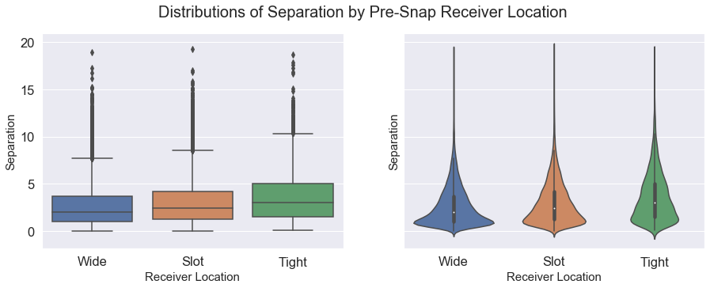

```python
#Look at the distributions of Separation by Pre-Snap Receiver Location

fig, (ax1, ax2) = plt.subplots(ncols=2, sharey=True, figsize=(15,5))


sns.boxplot(x="Receiver_Location", y="Separation", data=Merged, ax = ax1, order = ['Wide', 'Slot', 'Tight'])
sns.violinplot(x="Receiver_Location", y="Separation", data=Merged, ax = ax2, order = ['Wide', 'Slot', 'Tight'])

fig.suptitle('Distributions of Separation by Pre-Snap Receiver Location', fontsize = 20)
ax1.set_ylabel('Separation', fontsize = 15)
ax1.set_xlabel('Receiver Location', fontsize = 15)
ax2.set_ylabel('Separation', fontsize = 15)
A = ax2.set_xlabel('Receiver Location', fontsize = 15)
```

There are marginal differences between the distributions of these three locations, and I am going to leave them as-is.

# Feature Analysis: Time

There are 60 minutes in an NFL football game, and I don't think there is any inherent difference that we should expect when it comes to separation when its the start of the 1st, 2nd, 3rd, or 4th quarter. I think there might be more interesting things to find, but I want to translate this MM:SS time string that I am given to an integer value of seconds left in game, and go from there.

```python
def time_to_seconds(time_str):
    #Change the string 'Time' to a value in seconds

    m, s = time_str.split(':')
    return int(m) * 60 + int(s)

#Quick check to make sure this function does what I am intending
print(str(Merged['Time'][3]) + ' is equal to ' + str(time_to_seconds(Merged['Time'][3])) + ' seconds')
print(str(Merged['Time'][50]) + ' is equal to ' + str(time_to_seconds(Merged['Time'][50])) + ' seconds')
print(str(Merged['Time'][302]) + ' is equal to ' + str(time_to_seconds(Merged['Time'][302])) + ' seconds')
```

```
6:45 is equal to 405 seconds
10:29 is equal to 629 seconds
13:46 is equal to 826 seconds
```

I found a bug with the function, because it didn't know how to treat 'nan' Time values. These were not found earlier because they are 'non as strings, not the Nans that pandas recognizes. Let's remove them now.

```python
Merged['Time'] = Merged['Time'].astype(str)
Merged = Merged[Merged['Time'] != 'nan']
```

```python
Merged['Time_in_Sec'] = Merged['Time'].apply(time_to_seconds)
```

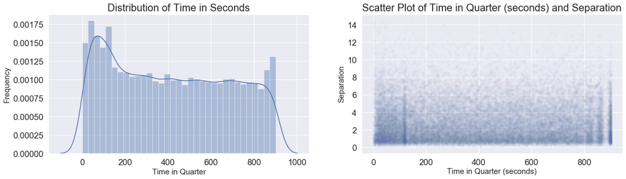

```python
x = Merged['Time_in_Sec']
y = Merged['Separation']

fig, (ax1, ax2) = plt.subplots(ncols=2, figsize=(20, 5))

sns.distplot(x, ax = ax1)
sns.scatterplot(x=x, y = y, alpha = 0.02)

ax1.set_title('Distribution of Time in Seconds', fontsize = 20)
ax1.set_ylabel('Frequency', fontsize = 15)
ax1.set_xlabel('Time in Quarter', fontsize = 15)

ax2.set_title('Scatter Plot of Time in Quarter (seconds) and Separation', fontsize = 20)
ax2.set_ylabel('Separation', fontsize = 15)
A = ax2.set_xlabel('Time in Quarter (seconds)', fontsize = 15)
```

```python
print('Spearman (rank) correlation: ' + str(round(x.corr(y, method = 'spearman'), 3)) + ' between Time and Separation')
print('Pearson (linear) correlation: ' + str(round(x.corr(y, method = 'pearson'), 3)) + ' between Time and Separation')
```

```
Spearman (rank) correlation: 0.021 between Time and Separation
Pearson (linear) correlation: 0.015 between Time and Separation
```

As you might've guessed, the time left in a quarter has almost no correlation to the separation.

Let's do some feature engineering to see if we can get some more insight out of this feature.

# Feature Engineering: Time Left in Game/Time Left in Half

Its not enough to use just the time left in the quarter to understand how time left affects gameplay, especially receiver separation. Let's see if include Quarter into this measurement helps us understand more.

```python
Merged['sec_left_in_game'] = Merged['Time_in_Sec'] + ((4-Merged['Qtr'])*15*60)


#Check to see that this is doing what we are expecting

print(str(Merged['Time'][3]) + ' in the ' + str(Merged['Qtr'][3]) + 'rd Quarter is equal to ' + str(Merged['sec_left_in_game'][3]) + ' seconds')
print(str(Merged['Time'][30]) + ' in the ' + str(Merged['Qtr'][30]) + 'th Quarter is equal to ' + str(Merged['sec_left_in_game'][30]) + ' seconds')
print(str(Merged['Time'][302]) + ' in the ' + str(Merged['Qtr'][302]) + 'st Quarter is equal to ' + str(Merged['sec_left_in_game'][302]) + ' seconds')
```

```
6:45 in the 3rd Quarter is equal to 1305 seconds
7:24 in the 4th Quarter is equal to 444 seconds
13:46 in the 3st Quarter is equal to 1726 seconds
```

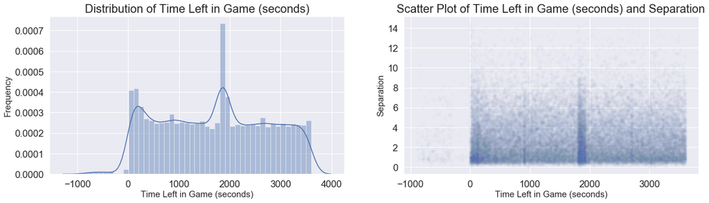

```python
x = Merged['sec_left_in_game']
y = Merged['Separation']

fig, (ax1, ax2) = plt.subplots(ncols=2, figsize=(20, 5))

sns.distplot(x, ax = ax1)
sns.scatterplot(x=x, y = y, alpha = 0.02)

ax1.set_title('Distribution of Time Left in Game (seconds)', fontsize = 20)
ax1.set_ylabel('Frequency', fontsize = 15)
ax1.set_xlabel('Time Left in Game (seconds)', fontsize = 15)

ax2.set_title('Scatter Plot of Time Left in Game (seconds) and Separation', fontsize = 20)
ax2.set_ylabel('Separation', fontsize = 15)
A = ax2.set_xlabel('Time Left in Game (seconds)', fontsize = 15)
```

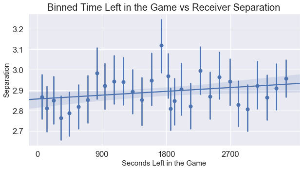

```python
x = Merged['sec_left_in_game']
y = Merged['Separation']

fig, ax = plt.subplots(figsize = (10,5))
sns.regplot(x=x, y = y, x_bins = 30)

ax.set_title('Binned Time Left in the Game vs Receiver Separation', fontsize = 20)
ax.set_ylabel('Separation', fontsize = 15)
plt.xticks(np.arange(0, 3600, step=900))
A = ax.set_xlabel('Seconds Left in the Game', fontsize = 15)
```

I cannot see any strong trends from the graph above, so let me take this a step further, by isolating time by halves.

## Feature Engineering: Time Left in Half

I would like to see if theres anything to the fact that 2 minute scenarios (ends of each half) might be more telling. I suspect that creating a new field called *'time left in half'* might be more insightful

```python
mask = (Merged['Qtr'] == 1) | (Merged['Qtr'] == 3)
Merged['sec_left_in_half'] = Merged['Time_in_Sec']
Merged['sec_left_in_half'][mask] = Merged['Time_in_Sec'] + 900
Merged.head()
```

|  | Nearest_Def_Position | Qtr | Time | Down | To Go | Receiver_Location | Cushion | Air_Yds | Air_Dist | Air_Time | ... | Down_Distance | Yds_to_Success | Yds_to_1st | yds_beyond_success | Cushion_Type | Sideline_Air_Yds | NDP | Time_in_Sec | sec_left_in_game | sec_left_in_half |
| --- | --- | --- | --- | --- | --- | --- | --- | --- | --- | --- | --- | --- | --- | --- | --- | --- | --- | --- | --- | --- | --- |
| 0 | SS | 3 | 3:15 | 3 | 9 | Slot | 3.66 | 24.54 | 33.119846 | 1.539 | ... | 3.000000 | 9.0 | 15.54 | 15.54 | Regular | 25.236671 | STY | 195 | 1095 | 1095 |
| 1 | CB | 3 | 10:47 | 1 | 10 | Wide | 2.66 | 27.23 | 37.510450 | 2.202 | ... | 10.000000 | 4.5 | 17.23 | 22.73 | Press | 41.926669 | CB | 647 | 1547 | 1547 |
| 2 | CB | 3 | 9:36 | 2 | 8 | Wide | 10.23 | 42.88 | 52.871040 | 2.633 | ... | 4.000000 | 4.4 | 34.88 | 38.48 | Off | 52.650000 | CB | 576 | 1476 | 1476 |
| 3 | CB | 3 | 6:45 | 3 | 8 | Wide | 6.74 | 39.44 | 49.233444 | 3.018 | ... | 2.666667 | 8.0 | 31.44 | 31.44 | Regular | 47.006672 | CB | 405 | 1305 | 1305 |
| 4 | SS | 2 | 3:46 | 1 | 10 | Wide | 3.23 | 39.06 | 46.187710 | 2.636 | ... | 10.000000 | 4.5 | 29.06 | 34.56 | Regular | 50.956670 | STY | 226 | 2026 | 226 |

5 rows × 27 columns

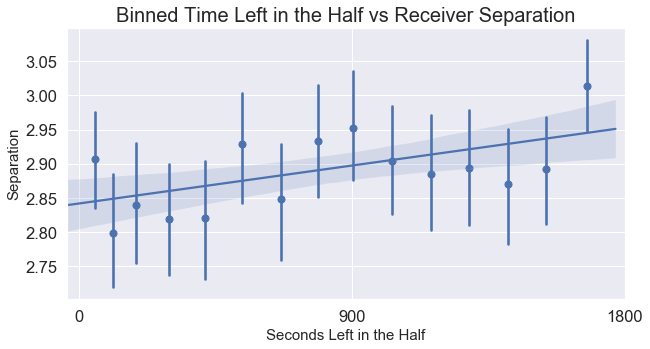

```python
x = Merged['sec_left_in_half']
y = Merged['Separation']

fig, ax = plt.subplots(figsize = (10,5))
sns.regplot(x=x, y = y,  x_bins = 15)

ax.set_title('Binned Time Left in the Half vs Receiver Separation', fontsize = 20)
ax.set_ylabel('Separation', fontsize = 15)
plt.xticks(np.arange(0, 2700, step=900))
A = ax.set_xlabel('Seconds Left in the Half', fontsize = 15)
```

```python
print('Spearman (rank) correlation: ' + str(round(x.corr(y, method = 'spearman'), 3)) + ' between Time and Separation')
print('Pearson (linear) correlation: ' + str(round(x.corr(y, method = 'pearson'), 3)) + ' between Time and Separation')
```

```
Spearman (rank) correlation: 0.023 between Time and Separation
Pearson (linear) correlation: 0.015 between Time and Separation
```

Turns out, this had little to **no effect** on my correlation values, but so it goes! I am going to try one more thing to see if it is potentially helpful. I am going to create a boolean for 'is_under_2_min' that checks whether the play comes with under 2 minuets left in the half.

## Feature Engineering: 2-Minute Drill?

Does the pass come with under 2 minutes left in a half?

```python
Merged['Under_2Min'] = 0
Merged['Under_2Min'].loc[Merged['sec_left_in_half'] <= 120] = 1

A = Merged['Under_2Min'].sum()
B = len(Merged)
C = round(((A/B)*100), 1)
print(str(A) + ' of ' + str(B) + ' targets came with under 2 min remaining in the half, or ' + str(C) + '% of all plays')
```

```
6273 of 43559 targets came with under 2 min remaining in the half, or 14.4% of all plays
```

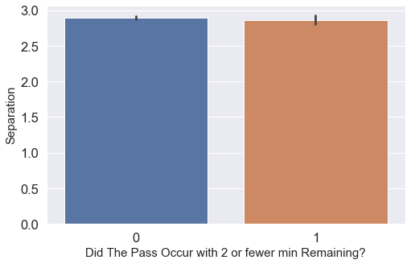

```python
x = Merged['Under_2Min']
y = Merged['Separation']
fig, ax = plt.subplots(figsize = (8,5))
sns.barplot(x=x, y=y)
ax.set_ylabel('Separation', fontsize = 15)
A = ax.set_xlabel('Did The Pass Occur with 2 or fewer min Remaining?', fontsize = 15)
```

Even after doing this work, unfortunately, **being under 2 min left in the half has almost no correlation** to receiver separation.

# Feature Selection

I would like to note that it would be perfectly fine to use all 21 features and see how it all turns out, but when potentially dealing with linear regression modeling we should be wary that including unessary, co-variate, or redundant features would only cloud our predictions.

> *Many models, especially those based on regression slopes and intercepts, will estimate parameters for every term in the model. Because of this, the presence of non-informative variables can add uncertainty to the predictions and reduce the overall effectiveness of the model.*

> Page 488, Applied Predictive Modeling, 2013.

```python
#Time is a string, we don't need it now that we have it in seconds, let's drop it

Merged = Merged.drop('Time', axis = 1)
Merged = Merged.drop('Time_in_Sec', axis = 1)
Merged = Merged.drop('Nearest_Def_Position', axis = 1)
Merged = Merged.drop('sec_left_in_game', axis = 1)
Merged = Merged.drop('Under_2Min', axis = 1)
```

```python
#Check to see how many null values there are left
Merged.info()
```

```
<class 'pandas.core.frame.DataFrame'>
Int64Index: 43559 entries, 0 to 53709
Data columns (total 23 columns):
Qtr                            43559 non-null int64
Down                           43559 non-null int64
To Go                          43559 non-null int64
Receiver_Location              43559 non-null object
Cushion                        43559 non-null float64
Air_Yds                        43559 non-null float64
Air_Dist                       43559 non-null float64
Air_Time                       43559 non-null float64
TTT                            43559 non-null float64
QB_Separation                  43559 non-null float64
QBP                            43559 non-null int64
Receiver_Dist_From_Sideline    43559 non-null float64
EZ_Dist                        43559 non-null float64
missing_cushion                43559 non-null int64
Separation                     43559 non-null float64
Down_Distance                  43559 non-null float64
Yds_to_Success                 43559 non-null float64
Yds_to_1st                     43559 non-null float64
yds_beyond_success             43559 non-null float64
Cushion_Type                   43559 non-null object
Sideline_Air_Yds               43559 non-null float64
NDP                            43559 non-null object
sec_left_in_half               43559 non-null int64
dtypes: float64(14), int64(6), object(3)
memory usage: 9.2+ MB
```

## Encoding Categorical Variables

Before we can start doing any worthwhile analysis, we have to encode our categorical variables into numerical ones so our linear/ML models can begin to understand what they represent. To do this, we will **1-HOT ENCODE** all our categorical variables, creating a new column for each possible value within each category. This isnt necessarily the most effective or accurate way to encode our variables, but it is tried and true, and creates a good baseline.

I want to test **Ordinal Encoded** categorical features as well, so I will make a separate dataset to see if that helps.

```python
# One-Hot Encode all categorical variables before modeling

Merged_Enc = pd.get_dummies(data = Merged)
print('We have', len(Merged_Enc.columns), 'features to help with predictions')
Merged_Enc.to_pickle("../data/Orig.pkl")
```

```
We have 30 features to help with predictions
```

```python
#Ordinal Encoded dataframe creation
from sklearn.preprocessing import OrdinalEncoder

#initialize encoder
Ordinal = OrdinalEncoder()

#Select categorical columns
Ord_Enc = Merged.select_dtypes(include=['object']).columns

#Encode categorical columns
Merged[Ord_Enc] = Ordinal.fit_transform(Merged[Ord_Enc])

#export df to pickle file
Merged.to_pickle("../data/OrdinalEnc.pkl")
```

### How are our newly created continuous features?

```python
float_col = Merged.select_dtypes(include=['float64'])
float_col = float_col.columns
```

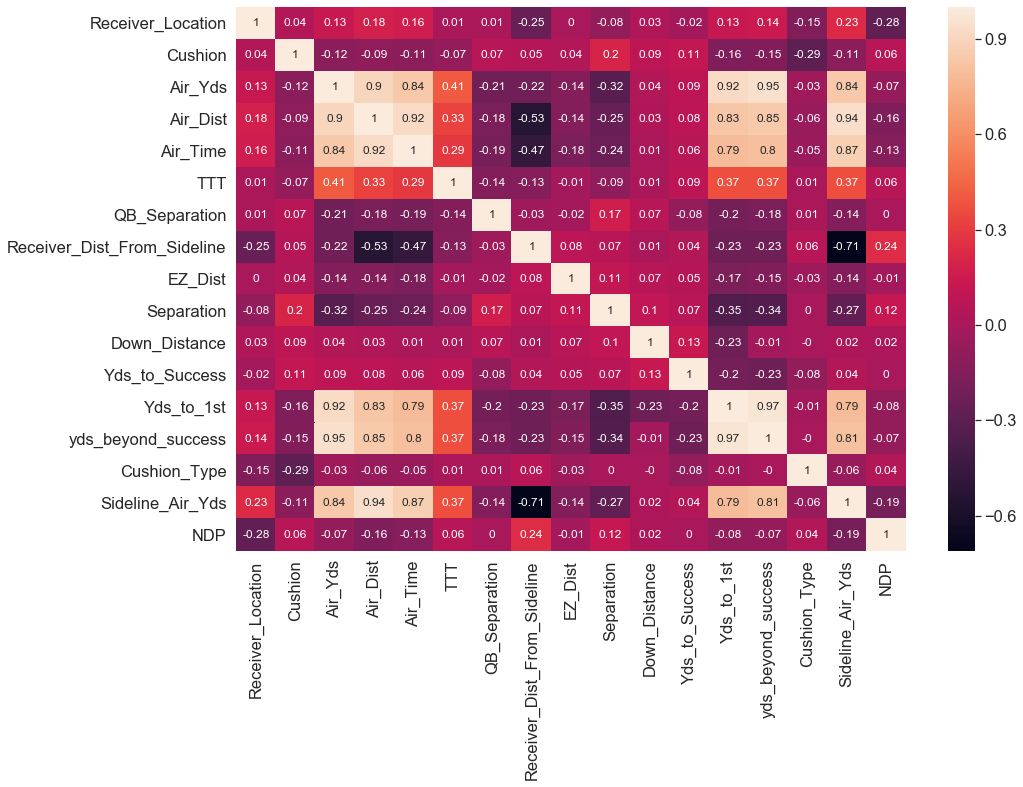

```python
fig =  plt.subplots(figsize=(15,10))
ax = sns.heatmap(round(Merged[float_col].corr(method = 'pearson'), 2), annot=True, annot_kws={"size": 12})
```

It appears that **'Yds_to_1st'** is the most negatively correleated feature now, more than Air_Yds.

It is worth noting that Air_Yds, Air_Dist, Yds_to_1st, and yds_beyond_success are all highly correlated to each other, so we will likely end up with just 1 or 2 of these 4 features in our final model.

# How are the categorical features that we created?

Since categorical features behave inherently non-continuously, we will use the **Kendall Tau** rank correlation metric to measure our categorical features relationship with Separation.

```python
Cat_cols = ['Receiver_Location_Slot', 'Receiver_Location_Tight',
       'Receiver_Location_Wide','Cushion_Type_Off', 'Cushion_Type_Press',
       'Cushion_Type_Regular', 'NDP_CB', 'NDP_DL', 'NDP_LB', 'NDP_STY', 'Separation']
```

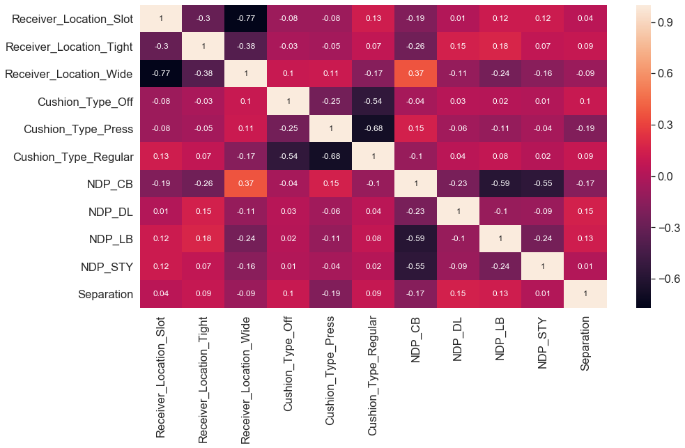

```python
fig =  plt.subplots(figsize=(15,8))
ax = sns.heatmap(round(Merged_Enc[Cat_cols].corr(method = 'kendall'), 2), annot=True, annot_kws={"size": 12})
```

**Cushion_Type_Press** (-.19), **NDP_CB** (-.17), and **NDP_DL** (0.15) are the leading categorical candidates in influencing our final model.

We can see how they affected my final model in the next notebook (Model Selection and Tuning)

```python
# Some ML models (xgboost, LGMB) can impute missing values efficiently themselves, and will not need the values I've imputed manually

Missing = Merged_Enc.copy()
Missing.loc[Missing.missing_cushion==1, 'Cushion'] = np.nan
Missing.to_pickle("../data/Missing.pkl")
```